# Tiktok feed across a week

# What’s going on with this data?

My Tiktok feed is shaped by the recommendation algorithm within the app and engagement levels can change depending on time of day, video length and content type. Throughout a week I logged daily observations, viewing at least 15 videos on the app every day and at one of the four preselected periods in a day. 21 observations were recorded, noting content type, average video length and the overall level of engagement I felt from watching the videos. The total number of videos watched was 415 and the average length of all videos was 41.1 seconds.

## Observations logged

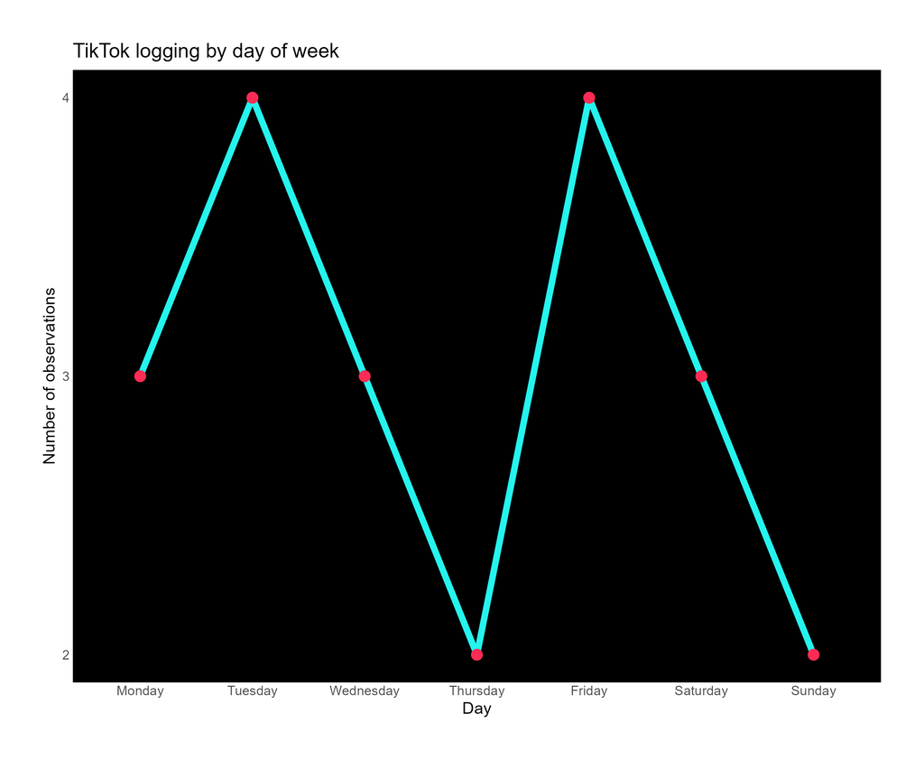

Line graph showing the number of TikTok observations recorded across the week.

Observations were highest on Tuesday and Friday, while Thursday and Sunday had the fewest recordings. Overall, logging activity was relatively consistent across the week with only small daily changes.

## Content type

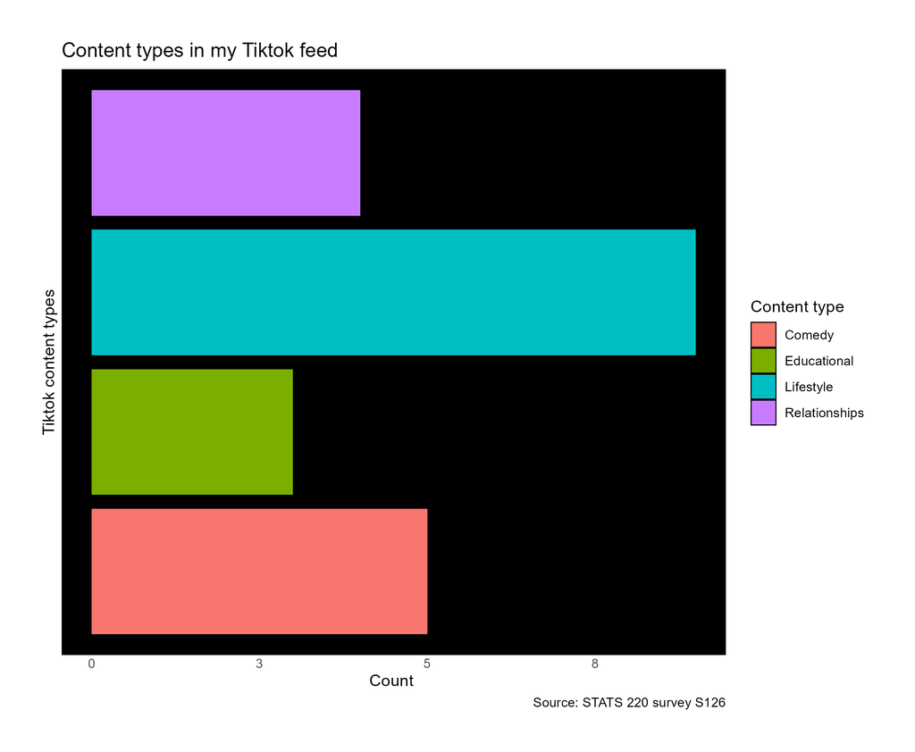

Horizontal bar chart showing the number of TikTok videos observed for four content types

Out of the 10 categories in the survey, the videos were related to only 4 categories with ‘Lifestyle’ content was the most frequently observed category in my TikTok feed. This suggests that the algorithm is strongly tailored toward content related to everyday living topics that I’m interested in such as DIY and frugal living. Other content types appeared less frequently, indicating that my feed is not evenly distributed across categories. Educational and relationship videos appeared less frequently, while comedy content was moderately common.

## Engagement levels

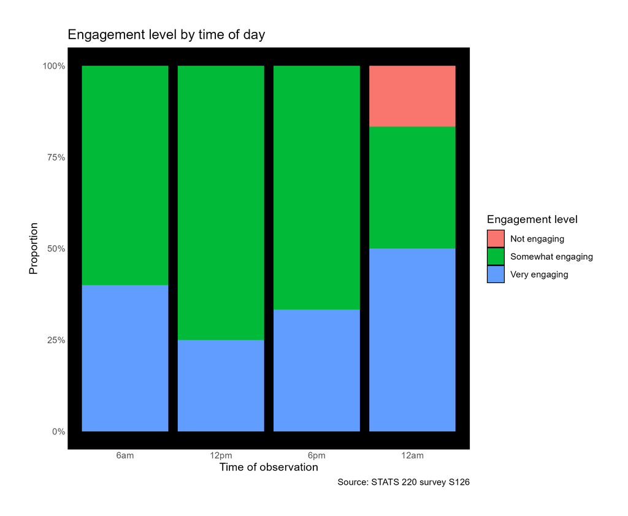

Stacked bar chart showing the proportion of TikTok engagement levels at four observation times

## Video length, engagement and content type

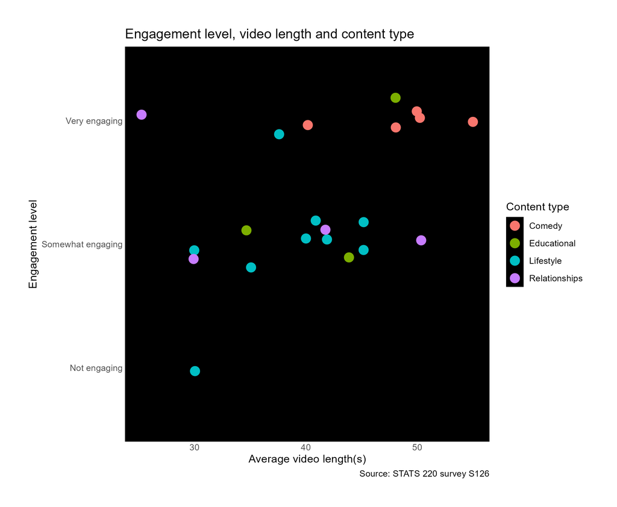

Scatterplot showing the relationship between TikTok engagement level, average video length, and content type

Higher engagement levels were often associated with longer videos, especially comedy content between 45 and 55 seconds long. Lifestyle videos showed more mixed engagement levels, including the only video rated as “Not engaging”. Longer funny videos (Comedy) garnered higher “Very engaging” responses compared to other content types.

## Average video length and content type

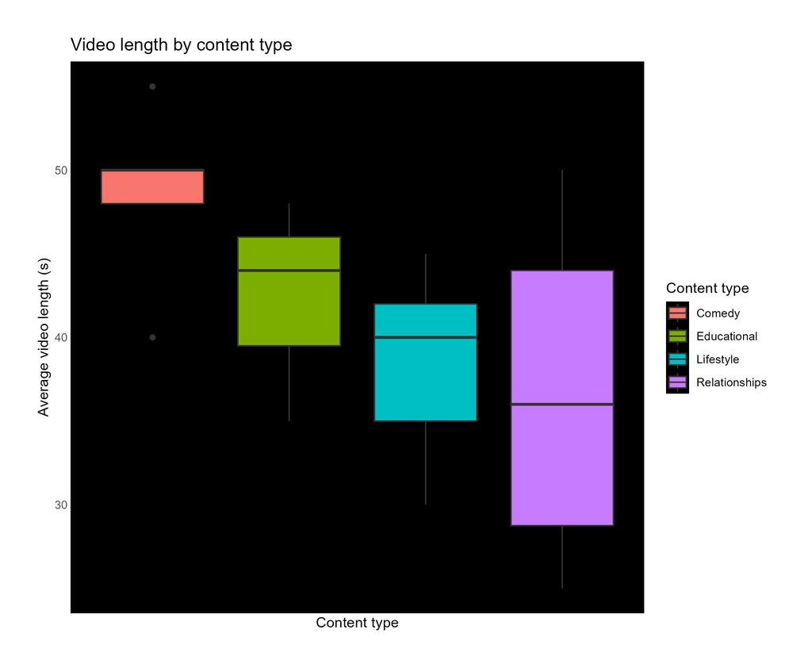

Boxplot comparing average TikTok video lengths across four content types: Comedy, Educational, Lifestyle,and Relationships